# inclass-week6

Author

Ziyang Ye

### Activity 1

```r
library(randomForest)
# data cleaning
dat <- read.csv("cherry-bloom-early.csv")
dat_sub <- dat[, c("early_bloom", grep("tmax", names(dat), value = TRUE))]
dat_sub$early_bloom <- trimws(dat_sub$early_bloom)   # 去掉前后空格
dat_sub$early_bloom <- tolower(dat_sub$early_bloom)  # 转小写
dat_sub$early_bloom <- factor(dat_sub$early_bloom, levels = c("no", "yes"))

# check "no"/"yes"
print(table(dat_sub$early_bloom, useNA = "ifany"))
```

```
 no yes
153  40
```

```r
p <- ncol(dat_sub) - 1
m_values <- round(seq(1, p, length.out = 3))
T_values <- seq(200, 1000, length.out = 5)
grid <- expand.grid(m = m_values, T = T_values)
grid_list <- apply(grid, 1, function(row) {
  list(m = row["m"], T = row["T"])
})
print(grid_list)
```

```
[[1]]
[[1]]$m
m
1

[[1]]$T
  T
200


[[2]]
[[2]]$m
m
4

[[2]]$T
  T
200


[[3]]
[[3]]$m
m
6

[[3]]$T
  T
200


[[4]]
[[4]]$m
m
1

[[4]]$T
  T
400


```

[output cut: 93 more lines]

```
4

[[14]]$T
   T
1000


[[15]]
[[15]]$m
m
6

[[15]]$T
   T
1000
```

### Activity 2

```r
set.seed(123)
create_folds <- function(n, nfolds, strata) {
  folds <- vector("list", nfolds)
  for (s in unique(strata)) {
    idx <- which(strata == s)
    idx <- sample(idx)
    base_size <- length(idx) %/% nfolds
    remainder <- length(idx) %% nfolds
    fold_sizes <- rep(base_size, nfolds)
    if (remainder > 0) {
      fold_sizes[1:remainder] <- fold_sizes[1:remainder] + 1
    }
    start <- 1
    for (i in 1:nfolds) {
      end <- start + fold_sizes[i] - 1
      folds[[i]] <- c(folds[[i]], idx[start:end])
      start <- end + 1
    }
  }
  folds
}

fold_indices <- create_folds(
  n = nrow(dat_sub),
  nfolds = 5,
  strata = dat_sub$early_bloom
)
fold_indices
```

```
[[1]]
 [1]  14  64 150  51 192 188 113 114 183 115 173 126  90  29   7 179  99 103 187
[20] 131 149  96  37 138 175   9  49  92  25  32  75  94  54  45  98  23  60  39
[39] 189

[[2]]
 [1]  68 164 154 157 120  46 112  40 116  87 177 167  80  13 104 122 182  27 168
[20]  22 100 162  59 184 155 119  16 117   6 141 109  57 123  30 159  62 181  76
[39] 106

[[3]]
 [1] 180  47  36 172 190 147   4 165 142 133  67  24 166 136  41  48  35  12 148
[20]  95  82 186  85 160  44   8  66  10 110  50  55  18 156 121  53 101  81  52
[39]  43

[[4]]
 [1] 134  89 102 161  21  58  17  70  97 140 152 144  15  26  86 171 153  34  61
[20] 139 176 132 130  77 151   5 135 185 127 170  78 124 137 146  65 193 158 145

[[5]]
 [1] 129  11 108  72  88  20 105  73 163 178   2  38 107  79  91  33   1  84  69
[20]  63  19 125   3  42  74 111 174  71  83  56 169  28 118 128  31 143  93 191
```

### Activity 3

```r
# Load packages
library(randomForest)
library(pROC)
library(parallel)

# 1. Create a PSOCK cluster (2 nodes)
cl <- makePSOCKcluster(2)

# 2. Export objects to workers
clusterExport(cl, c("dat_sub", "grid_list", "fold_indices"), envir = environment())
clusterEvalQ(cl, library(randomForest))
```

```
[[1]]
[1] "randomForest" "stats"        "graphics"     "grDevices"    "utils"
[6] "datasets"     "methods"      "base"

[[2]]
[1] "randomForest" "stats"        "graphics"     "grDevices"    "utils"
[6] "datasets"     "methods"      "base"
```

```r
# 3. Parallel loop over folds
fold_results <- clusterApply(cl, fold_indices, function(test_idx) {
  train_data <- dat_sub[-test_idx, ]
  test_data  <- dat_sub[ test_idx, ]

  # Ensure factor response
  if(!is.factor(train_data[, 1])) train_data[, 1] <- as.factor(train_data[, 1])
  pos_class <- levels(train_data[, 1])[2]  # assume "yes"

  # Fit RF for each hyper-param combo
  res <- vector("list", length(grid_list))
  for(i in seq_along(grid_list)) {
    m_val <- grid_list[[i]]$m
    T_val <- grid_list[[i]]$T

    rf_fit <- randomForest(x = train_data[, -1], y = train_data[, 1],
                           mtry = m_val, ntree = T_val)
    preds <- predict(rf_fit, newdata = test_data[, -1], type = "prob")[, pos_class]
    res[[i]] <- list(predicted = preds, true = test_data[, 1])
  }
  res
})

# 4. Stop cluster
stopCluster(cl)

# 5. Compute AUC for each combo
G <- length(grid_list)
auc_results <- vector("list", G)

for(i in 1:G) {
  preds <- unlist(lapply(fold_results, function(x) x[[i]]$predicted))
  trues <- unlist(lapply(fold_results, function(x) x[[i]]$true))
  # Factor with "no" first, "yes" second
  trues <- factor(trues, levels = c("no", "yes"))

  if(length(unique(trues)) < 2) {
    warning(paste("Combo", i, "has only one class."))
    auc_val <- NA
  } else {
    roc_obj <- roc(trues, preds, levels = rev(levels(trues)))
    auc_val <- auc(roc_obj)
  }
  auc_results[[i]] <- list(auc = auc_val, predicted = preds, true = trues)
}
# 6. Show AUCs
auc_values <- sapply(auc_results, function(x) x$auc)
print(auc_values)
```

```
 [1] 0.6774510 0.6742647 0.6644608 0.6775327 0.6856209 0.6634804 0.6681373
 [8] 0.6713235 0.6618464 0.6615196 0.6784314 0.6649510 0.6629085 0.6806373
[15] 0.6616013
```

### Activity 4

1. **Parallel over $R$**
   - Each replication (running $K$ folds and $G$ combos) is a task.
   - Fewer, larger tasks. Less communication overhead, but can underuse cores if $R$ is small.
2. **Parallel over $K$**
   - Each fold is a task.
   - Medium-sized tasks, moderate communication. Can keep cores busy if $K$ is large.
3. **Parallel over $G$** Each hyper-parameter combo is a task. If $G$ is small, not enough tasks; if $G$ is large, overhead grows.
4. **Flatten over $R \times K$** Each fold in each replication is a task (still runs all $G$ combos). More tasks, better resource usage. Moderate communication.
5. **Flatten over $R \times K \times G$** Each (replication, fold, combo) is a separate task. Many small tasks. High communication overhead but maximum concurrency.

discussion part:Larger tasks (1 or 2) reduce communication but may leave cores idle.Smaller tasks (5) fully occupy cores but increase overhead. **Choice**  
Flattening over $R \times K$ (strategy 4) typically balances task size and number of tasks. Each fold handles all $G$ combos, avoiding too many tiny tasks, yet providing enough parallelism to keep workers busy.

### Activity 5

```r
R <- 3
K <- length(fold_indices)  # Number of folds
G <- length(grid_list)     # Number of hyper-param combos

# Replicate the K-fold indices for R replications, then flatten
rep_folds <- replicate(R, fold_indices, simplify = FALSE)
all_folds <- do.call(c, rep_folds)  # length = R*K

# Create a cluster and export data
cl <- makePSOCKcluster(2)
clusterExport(cl, c("dat_sub", "grid_list", "all_folds"), envir = environment())
clusterEvalQ(cl, library(randomForest))
```

```
[[1]]
[1] "randomForest" "stats"        "graphics"     "grDevices"    "utils"
[6] "datasets"     "methods"      "base"

[[2]]
[1] "randomForest" "stats"        "graphics"     "grDevices"    "utils"
[6] "datasets"     "methods"      "base"
```

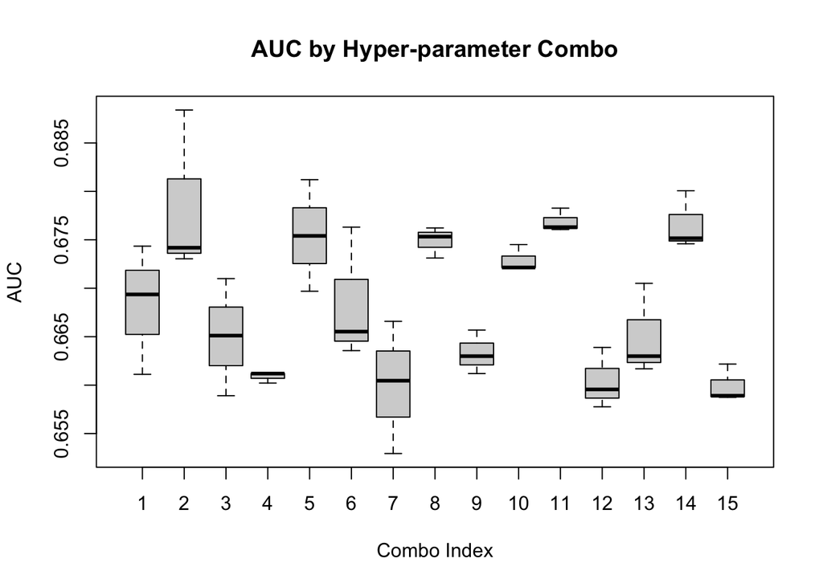

```r
# Parallel over R*K folds
fold_results <- clusterApply(cl, seq_along(all_folds), function(i) {
  test_idx <- all_folds[[i]]
  train_data <- dat_sub[-test_idx, ]
  test_data  <- dat_sub[ test_idx, ]

  if(!is.factor(train_data[,1])) train_data[,1] <- as.factor(train_data[,1])
  pos_class <- levels(train_data[,1])[2]

  # For each hyper-param combo
  res <- vector("list", length(grid_list))
  for(gid in seq_along(grid_list)) {
    rf_fit <- randomForest(
      x = train_data[, -1],
      y = train_data[, 1],
      mtry = grid_list[[gid]]$m,
      ntree = grid_list[[gid]]$T
    )
    preds <- predict(rf_fit, newdata = test_data[, -1], type = "prob")[, pos_class]
    res[[gid]] <- list(predicted = preds, true = test_data[,1])
  }
  res
})

stopCluster(cl)

# fold_results is length R*K; each element is a list of length G.

# Compute AUC for each replication and hyper-param combo
results_df <- data.frame(Rep = integer(), Combo = integer(), AUC = numeric())

for(rp in 1:R) {
  # Folds for replication rp
  fold_ids <- ((rp - 1)*K + 1):(rp*K)

  for(gid in 1:G) {
    # Aggregate predictions across K folds
    all_preds <- unlist(lapply(fold_ids, function(f) fold_results[[f]][[gid]]$predicted))
    all_true  <- unlist(lapply(fold_ids, function(f) fold_results[[f]][[gid]]$true))

    all_true <- factor(all_true, levels = c("no", "yes"))
    if(length(unique(all_true)) < 2) {
      auc_val <- NA
    } else {
      roc_obj <- roc(all_true, all_preds, levels = rev(levels(all_true)))
      auc_val <- auc(roc_obj)
    }

    results_df <- rbind(
      results_df,
      data.frame(Rep = rp, Combo = gid, AUC = auc_val)
    )
  }
}
# Boxplots of AUC by combo
boxplot(AUC ~ Combo, data = results_df,
        main = "AUC by Hyper-parameter Combo",
        xlab = "Combo Index", ylab = "AUC")
```

```r
library(dplyr)
summary_stats <- results_df %>%
  group_by(Combo) %>%
  summarize(meanAUC = mean(AUC, na.rm = TRUE)) %>%
  arrange(desc(meanAUC))

print(summary_stats)
```

```
# A tibble: 15 × 2
   Combo meanAUC
   <int>   <dbl>
 1     2   0.679
 2    11   0.677
 3    14   0.677
 4     5   0.675
 5     8   0.675
 6    10   0.673
 7     6   0.668
 8     1   0.668
 9    13   0.665
10     3   0.665
11     9   0.663
12     4   0.661
13    12   0.660
14     7   0.660
15    15   0.660
```

```r
cat("Best combo by mean AUC:", summary_stats$Combo[1], "\n")
```

```
Best combo by mean AUC: 2
```

### Activity 6

Repeat the previous code (flatten over $R \times K$) but create a cluster with 20 cores and measure elapsed time via `system.time()`. Then do the same with the physical core count (`detectCores(logical = FALSE)`) and compare.

```r
R <- 3
K <- length(fold_indices)
G <- length(grid_list)

# Replicate the K-fold indices for R replications, then flatten
rep_folds <- replicate(R, fold_indices, simplify = FALSE)
all_folds <- do.call(c, rep_folds)  # length = R*K

# 1. Time on 20 cores
time_20 <- system.time({
  cl_20 <- makePSOCKcluster(20)
  clusterExport(cl_20, c("dat_sub", "grid_list", "all_folds"), envir = environment())
  clusterEvalQ(cl_20, library(randomForest))

  fold_results_20 <- clusterApply(cl_20, seq_along(all_folds), function(i) {
    # Same training+prediction code as in Activity 5 (no boxplots)
    test_idx <- all_folds[[i]]
    train_data <- dat_sub[-test_idx, ]
    test_data  <- dat_sub[ test_idx, ]
    if(!is.factor(train_data[,1])) train_data[,1] <- as.factor(train_data[,1])
    pos_class <- levels(train_data[,1])[2]

    res <- vector("list", length(grid_list))
    for(gid in seq_along(grid_list)) {
      rf_fit <- randomForest(
        x = train_data[, -1],
        y = train_data[, 1],
        mtry = grid_list[[gid]]$m,
        ntree = grid_list[[gid]]$T
      )
      preds <- predict(rf_fit, newdata = test_data[, -1], type = "prob")[, pos_class]
      res[[gid]] <- list(predicted = preds, true = test_data[,1])
    }
    res
  })

  stopCluster(cl_20)
})

time_20
```

```
   user  system elapsed
  0.013   0.011   2.150
```

```r
# 2. Time on physical core count
n_cores <- detectCores(logical = FALSE)
time_phys <- system.time({
  cl_phys <- makePSOCKcluster(n_cores)
  clusterExport(cl_phys, c("dat_sub", "grid_list", "all_folds"), envir = environment())
  clusterEvalQ(cl_phys, library(randomForest))

  fold_results_phys <- clusterApply(cl_phys, seq_along(all_folds), function(i) {
    # Same code block
    test_idx <- all_folds[[i]]
    train_data <- dat_sub[-test_idx, ]
    test_data  <- dat_sub[ test_idx, ]
    if(!is.factor(train_data[,1])) train_data[,1] <- as.factor(train_data[,1])
    pos_class <- levels(train_data[,1])[2]

    res <- vector("list", length(grid_list))
    for(gid in seq_along(grid_list)) {
      rf_fit <- randomForest(
        x = train_data[, -1],
        y = train_data[, 1],
        mtry = grid_list[[gid]]$m,
        ntree = grid_list[[gid]]$T
      )
      preds <- predict(rf_fit, newdata = test_data[, -1], type = "prob")[, pos_class]
      res[[gid]] <- list(predicted = preds, true = test_data[,1])
    }
    res
  })

  stopCluster(cl_phys)
})

time_phys
```

```
   user  system elapsed
  0.006   0.004   1.778
```